# PA2_template.Rmd

Carlo Bonini

Sunday, July 20, 2014

Here is the preprocessing code:

```r
raw<-read.csv("activity.csv")

good<-complete.cases(raw)

goodies<-raw[good,]
```

Here I make a simple histogram of steps taken on a daily basis:

```r
library(sqldf)
day_steps<-sqldf("select distinct(date), sum(steps) from goodies group by date")
```

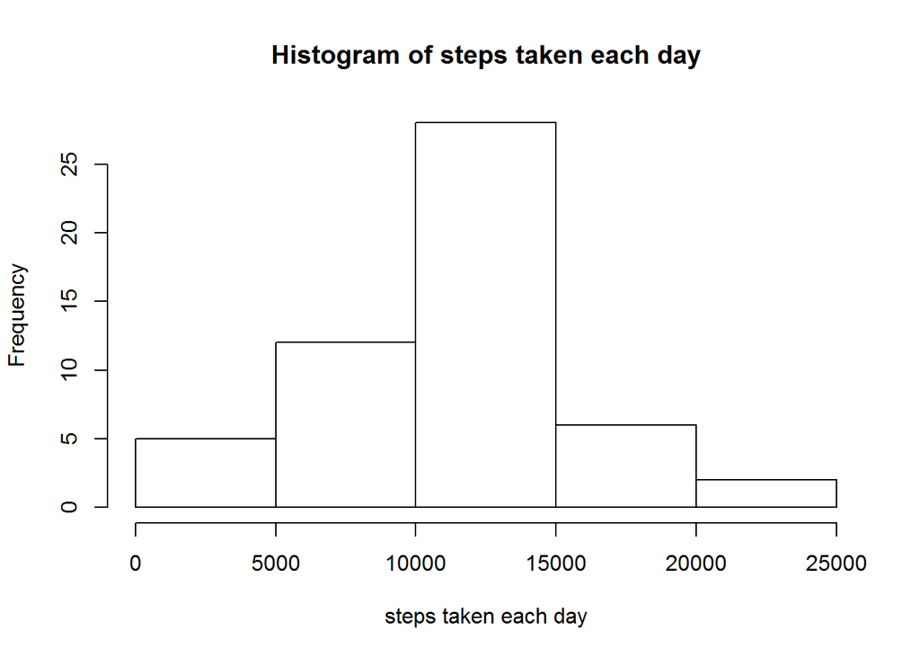

```r
hist(day_steps[,2],xlab="steps taken each day",main="Histogram of steps taken each day")
```

While in this other code chunk I calculate both Mean and Median:

```r
average_daily_steps<-mean(day_steps[,2])

Median_daily_steps<-median(day_steps[,2])

average_daily_steps
```

```
## [1] 10766
```

```r
Median_daily_steps
```

```
## [1] 10765
```

First, I compute the raw data in order to have a Tiny data sets to further computations,and then I make a simple time_series plot using the Base-Plotting system of the average steps taken by interval, averaged across all days:

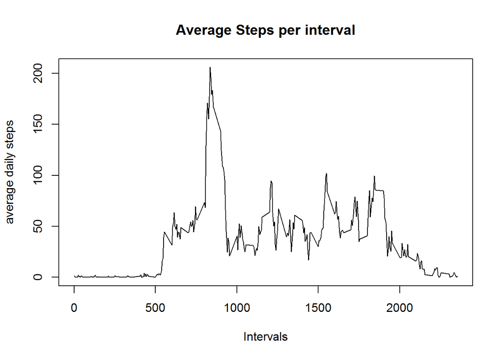

```r
average_daily_steps_per_interval<-sqldf("select interval, avg(steps) from goodies group by interval")

plot(average_daily_steps_per_interval[,1],
     average_daily_steps_per_interval[,2],type="l",main="Average Steps per interval",xlab="Intervals",ylab="average daily steps")
```

Finally I calculate the interval during the day that scored the highest number of steps (the result also the number of steps) :

```r
max_steps_interval<-subset(average_daily_steps_per_interval,
                           average_daily_steps_per_interval[,2]==
                               max(average_daily_steps_per_interval[,2]))

max_steps_interval
```

```
##     interval avg(steps)
## 104      835      206.2
```

The total number of NAs is

```r
Number_of_NA<-as.data.frame(length(raw[is.na(raw)]))

Number_of_NA
```

```
##   length(raw[is.na(raw)])
## 1                    2304
```

```r
merged_raw_average<-merge(average_daily_steps_per_interval,raw,by="interval")


for (i in 1:nrow(merged_raw_average)) {

  if (is.na(merged_raw_average[i,3])){

  merged_raw_average[i,3]<-merged_raw_average[i,2]

  }

}
```

I made a histogram of the total number of steps taken each day and Calculate and report the mean and median total number of steps taken per day.

The values don’t differ from the estimates from the first part of the assignment.

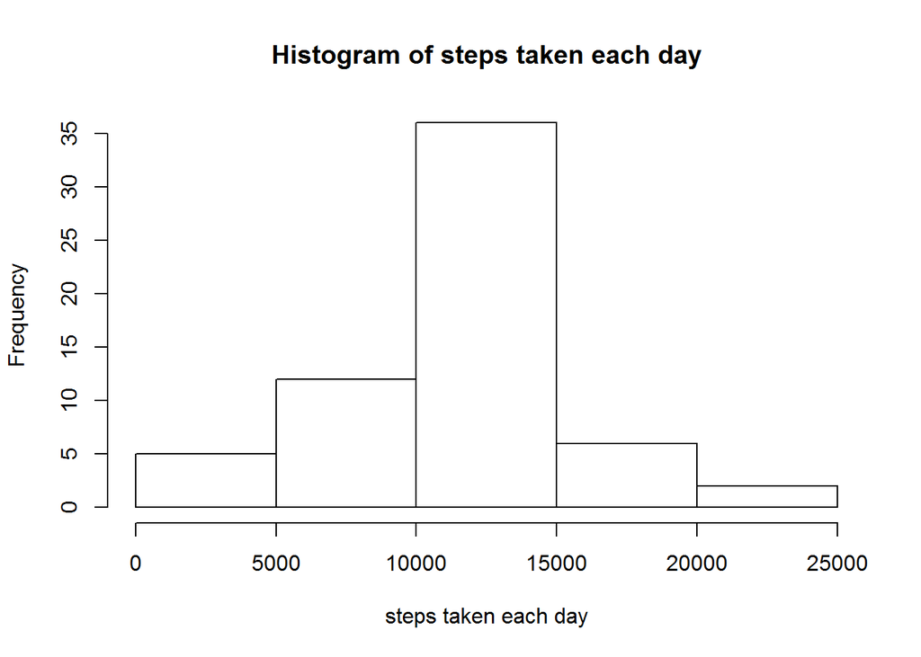

```r
day_steps_new<-sqldf("select distinct(date), sum(steps) from merged_raw_average group by date")

hist(as.numeric(as.character(day_steps_new[,2])),xlab="steps taken each day",main="Histogram of steps taken each day")
```

```r
average_daily_steps_new<-mean(day_steps_new[,2])

median_daily_steps_new<-median(day_steps_new[,2],na.rm = FALSE)

average_daily_steps_new
```

```
## [1] 10766
```

```r
median_daily_steps_new
```

```
## [1] 10766
```

So, the new data frame has 4 column and no NA’s. I transform the column of the date into a more useful format by assigning the weekdays value to each cell, so that is easy to understand whether a day is weekend or weekday.

```r
merged_raw_average[,4]<-as.Date(merged_raw_average[,4],origin="1960-01-01")

merged_raw_average[,4]<-weekdays(merged_raw_average[,4])
```

In the end I subset the final database using the package sqldf in order to get the average per interval across all days as above; I get two different dataframes per weekends data and weekdays data.

```r
weekend<-subset(merged_raw_average,merged_raw_average$date=="sabato" | merged_raw_average$date=="domenica")

weekend["type_of_day"]<-"weekend"

weekday<-subset(merged_raw_average,merged_raw_average$date!="sabato"&merged_raw_average$date!="domenica")

weekday["type_of_day"]<-"weekday"

final_database<-rbind(weekday,weekend)

weekday_average_daily_steps<-sqldf("select interval, avg(steps) from final_database where type_of_day= 'weekday' group by interval")

weekend_average_daily_steps<-sqldf("select interval, avg(steps) from final_database where type_of_day= 'weekend' group by interval")
```

Finally, we can make the plot using the base plotting system:

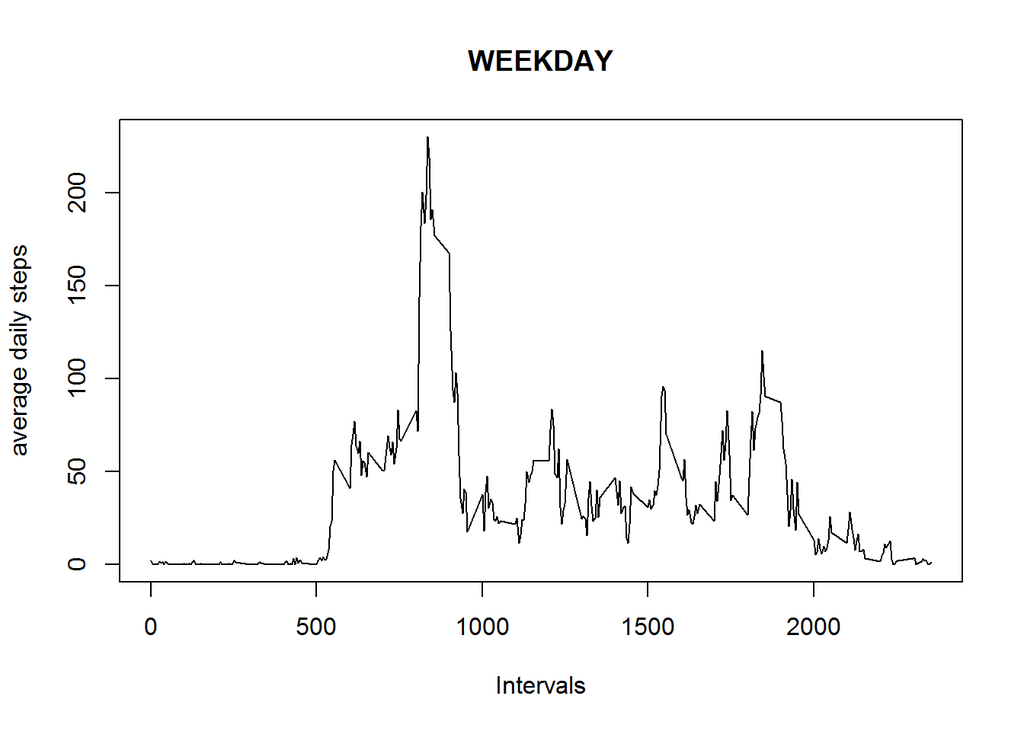

```r
plot(weekday_average_daily_steps[,1],
     weekday_average_daily_steps[,2],type="l",main="WEEKDAY",xlab="Intervals",ylab="average daily steps")
```

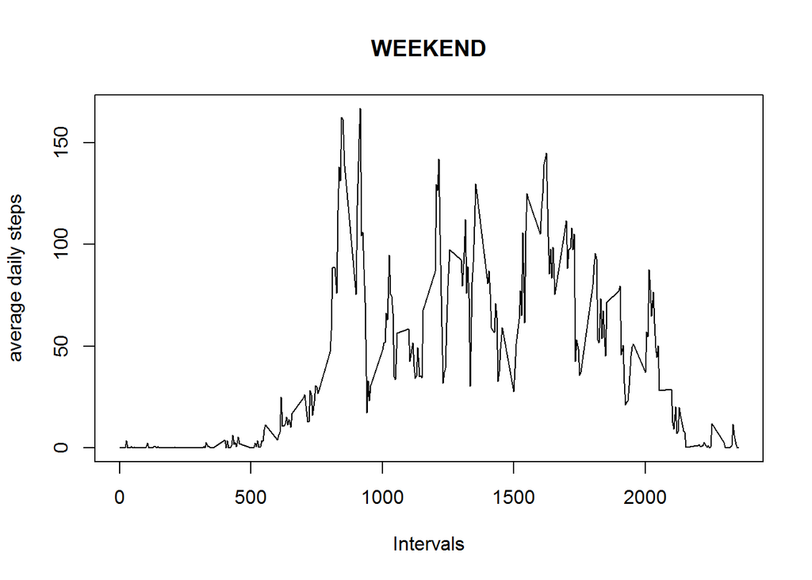

```r
plot(weekend_average_daily_steps[,1],
     weekend_average_daily_steps[,2],type="l",main="WEEKEND",xlab="Intervals",ylab="average daily steps")
```